```r
require(dplyr)
```

```r
library(dplyr)
library(ggplot2)
```

```r
Poland <- read.csv("final_datasets/Poland_combined__years_with_nan_dropped_True.csv")
Hungary <- read.csv("final_datasets/Hungary_combined__years_with_nan_dropped_True.csv")
Bulgaria <- read.csv("final_datasets/Bulgaria_combined__years_with_nan_dropped_True.csv")
```

Hypothesis: the birth rate changes depending on the population ageing

Fixing the dataset to include age as integer and not as a category

```r
fix.age <- function(df) {
  vec = c()
  for (age in df$Age) {
    if (grepl("80", age)) {
      vec <- append(vec, 80)
    }
    else {
      vec <-append(vec, mean(as.integer(unlist(strsplit(age, "-")))))
    }
  }
    return (vec)
}

Poland$Age.Int <- fix.age(Poland)
Hungary$Age.Int <- fix.age(Hungary)
Bulgaria$Age.Int <- fix.age(Bulgaria)
```

Extracting the birthrate, mean age

```r
get.data <- function(Country) {
  yrs = unique(Country$Year)
  birth.rates = c()
  mean.ages = c()
  for (yr in yrs) {
    by.year = (filter(Country, Year==yr))
    total.pop = sum(filter(by.year, Age.Int!=0.0)$Value)
    people.born = sum(filter(by.year, Age.Int==0.0)$Value)
    birth.rate = people.born/total.pop * 100
    mean.age = sum(filter(by.year, Age.Int!=0.0)$Value * filter(by.year, Age.Int!=0.0)$Age.Int)/total.pop
    birth.rates <- append(birth.rates, birth.rate)
    mean.ages <- append(mean.ages, mean.age)
  }
  data = data.frame(year = yrs, birth.rate = birth.rates, mean.age = mean.ages)
  return(data)
}

data.Poland <- get.data(Poland)
data.Hungary <- get.data(Hungary)
data.Bulgaria <- get.data(Bulgaria)
```

```r
data.Poland
```

```
##    year birth.rate mean.age
## 1  1968  1.6372812 31.17991
## 2  1972  1.6898073 32.08981
## 3  1973  1.7180297 32.28327
## 4  1976  1.9334441 32.75578
## 5  1977  1.9513740 32.85722
## 6  1978  1.7307895 33.01187
## 7  1979  1.9414406 33.02526
## 8  1980  1.9765608 33.08590
## 9  1981  1.9266289 33.14248
## 10 1982  1.9194224 33.20385
## 11 1983  1.9653200 33.26480
## 12 1984  1.9608624 33.29921
## 13 1985  1.8801125 33.31252
## 14 1986  1.7856086 33.34978
```

[output cut: 16 more lines]

Constructing a linear model to see the relationship between mean.age and birth.rate

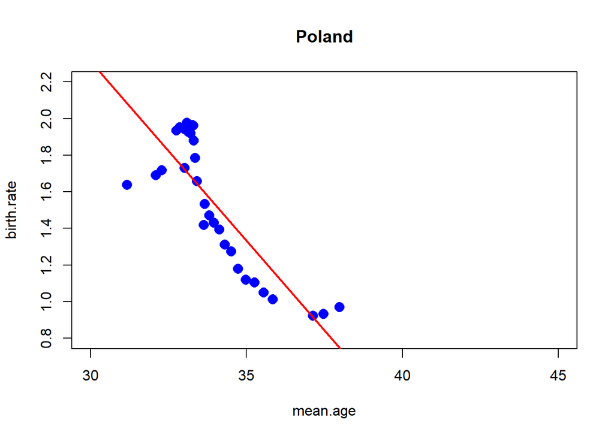

```r
plot.Country.mean.age <- function(data.Country, name) {
  data.Country.lm <- lm(birth.rate ~mean.age, data = data.Country)
  plot(data.Country$mean.age, data.Country$birth.rate, col = "blue", pch = 16, main = name, cex = 1.5, xlim = c(30, 45), ylim = c(0.8, 2.2), xlab="mean.age", ylab="birth.rate")

  abline(data.Country.lm, col = "red", lwd = 2)
  return(data.Country.lm)
}

data.Poland.lm.mean.age <- plot.Country.mean.age(data.Poland, "Poland")
```

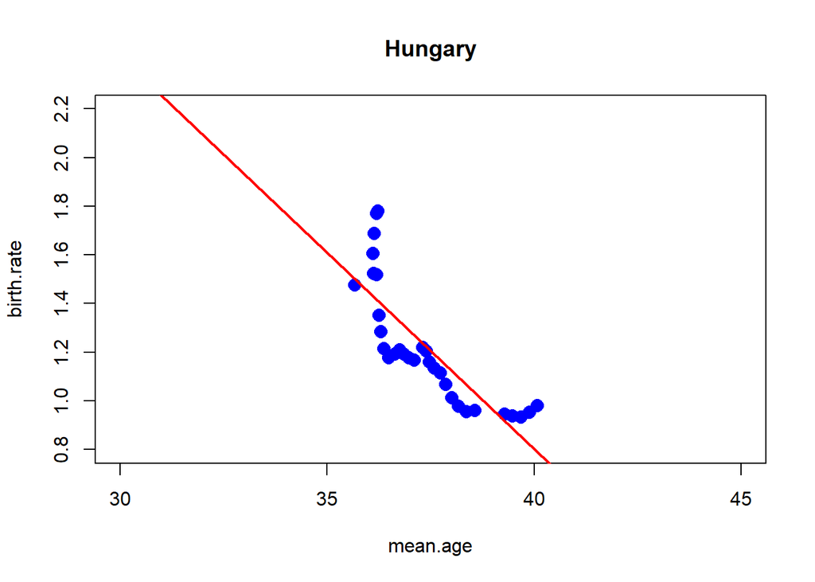

```r
data.Hungary.lm.mean.age <- plot.Country.mean.age(data.Hungary, "Hungary")
```

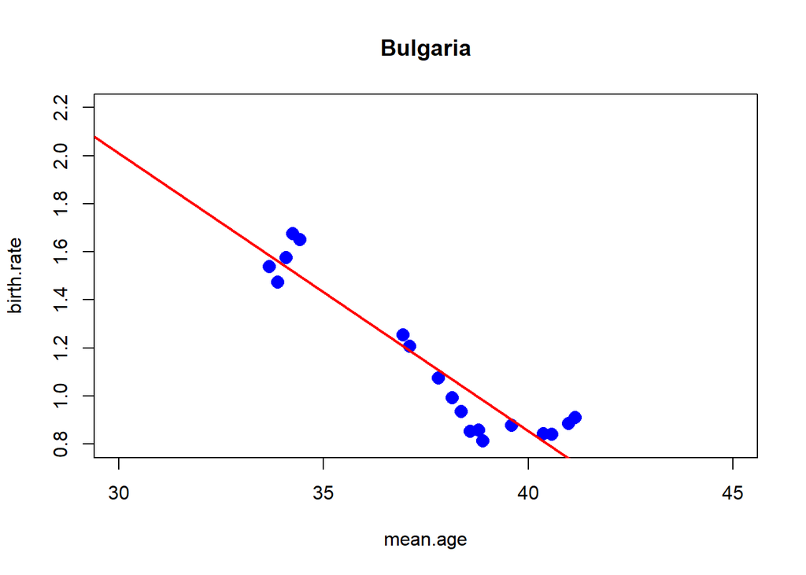

```r
data.Bulgaria.lm.mean.age <- plot.Country.mean.age(data.Bulgaria, "Bulgaria")
```

```r
summary(data.Poland.lm.mean.age)
```

```
##
## Call:
## lm(formula = birth.rate ~ mean.age, data = data.Country)
##
## Residuals:
##      Min       1Q   Median       3Q      Max
## -0.44370 -0.15548 -0.02676  0.21269  0.29533
##
## Coefficients:
##             Estimate Std. Error t value Pr(>|t|)
## (Intercept)  8.19323    0.81651  10.034 8.92e-11 ***
## mean.age    -0.19603    0.02398  -8.173 6.75e-09 ***
## ---
## Signif. codes:  0 '***' 0.001 '**' 0.01 '*' 0.05 '.' 0.1 ' ' 1
##
## Residual standard error: 0.2023 on 28 degrees of freedom
## Multiple R-squared:  0.7046, Adjusted R-squared:  0.6941
## F-statistic:  66.8 on 1 and 28 DF,  p-value: 6.75e-09
```

The p-value of the intercept and the coefficient is small, so we reject that they’re insignificant. The determination coefficient (0.7046) suggests that the model is pretty accurate

For Bulgaria and Hungary we got $r^2 =0.8755$ and $r^2 =0.6537$ respectively

The graphs form a curve, so there might be other dependencies

For example, the population structure

Lets see how the proportion of people who are capable of making children affects the birthrate

```r
get.structure <- function(Country, age.low, age.high) {
    yrs = unique(Country$Year)
  reproducible.age.proportions = c()
  for (yr in yrs) {
    by.year = (filter(Country, Year==yr))
    total.pop = sum(filter(by.year, Age.Int!=0.0)$Value)
    reproducible.age.proportion = sum(filter(by.year, Age.Int>=age.low & Age.Int<=age.high)$Value)/total.pop*100
    reproducible.age.proportions <-append(reproducible.age.proportions, reproducible.age.proportion)
  }
  return (reproducible.age.proportions)
}


data.Poland$reproduce <- get.structure(Poland, 17, 50)
data.Hungary$reproduce <- get.structure(Hungary, 17, 50)
data.Bulgaria$reproduce <- get.structure(Bulgaria, 17, 50)
```

Its important to choose the age range. Let it be 17-50

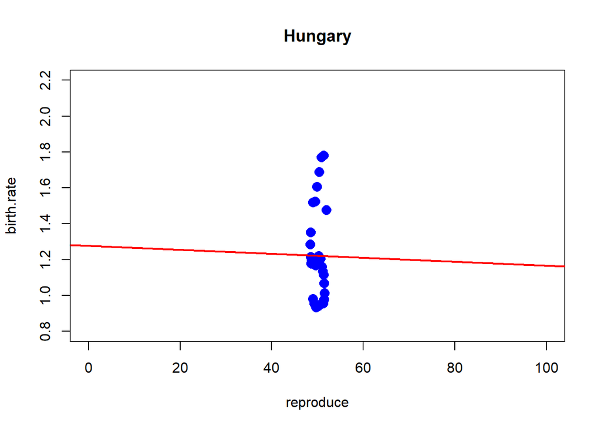

```r
plot.Country.reproduce <- function(data.Country, name) {
  data.Country.lm <- lm(birth.rate ~reproduce, data = data.Country)
  plot(data.Country$reproduce, data.Country$birth.rate, col = "blue", pch = 16, main = name, cex = 1.5, xlim = c(0,100), ylim = c(0.8, 2.2), xlab="reproduce", ylab="birth.rate")

  abline(data.Country.lm, col = "red", lwd = 2)
  return(data.Country.lm)
}

data.Hungary.lm.reproduce<- plot.Country.reproduce(data.Hungary, "Hungary")
```

Looking at the plot, one can see that this model doesn’t make much sense

```r
summary(data.Hungary.lm.reproduce)
```

```
##
## Call:
## lm(formula = birth.rate ~ reproduce, data = data.Country)
##
## Residuals:
##      Min       1Q   Median       3Q      Max
## -0.29003 -0.22438 -0.04624  0.09447  0.55965
##
## Coefficients:
##              Estimate Std. Error t value Pr(>|t|)
## (Intercept)  1.276335   2.140035   0.596    0.556
## reproduce   -0.001091   0.042701  -0.026    0.980
##
## Residual standard error: 0.2568 on 29 degrees of freedom
## Multiple R-squared:  2.25e-05,   Adjusted R-squared:  -0.03446
## F-statistic: 0.0006526 on 1 and 29 DF,  p-value: 0.9798
```

Just to be sure, the p-value suggests that we cannot reject that the coefficients are zero

But what if we use instead more “productive” years?

```r
data.Poland$reproduce <- get.structure(Poland, 17, 40)
data.Hungary$reproduce <- get.structure(Hungary, 17, 40)
data.Bulgaria$reproduce <- get.structure(Bulgaria, 17, 40)
```

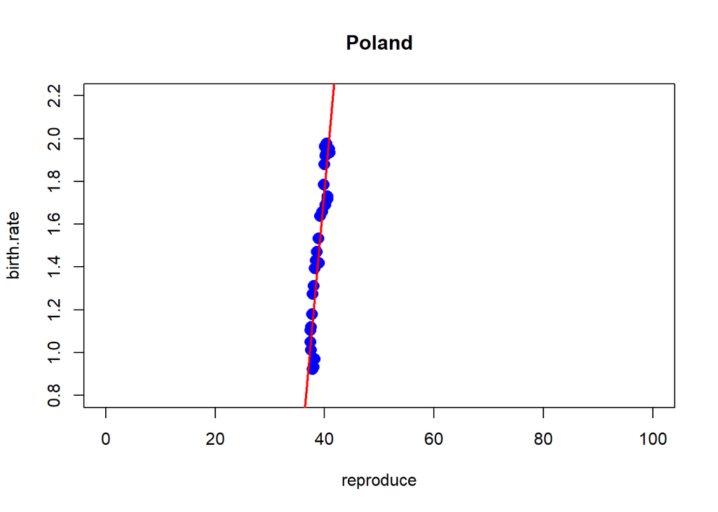

```r
data.Poland.lm.reproduce <- plot.Country.reproduce(data.Poland, "Poland")
```

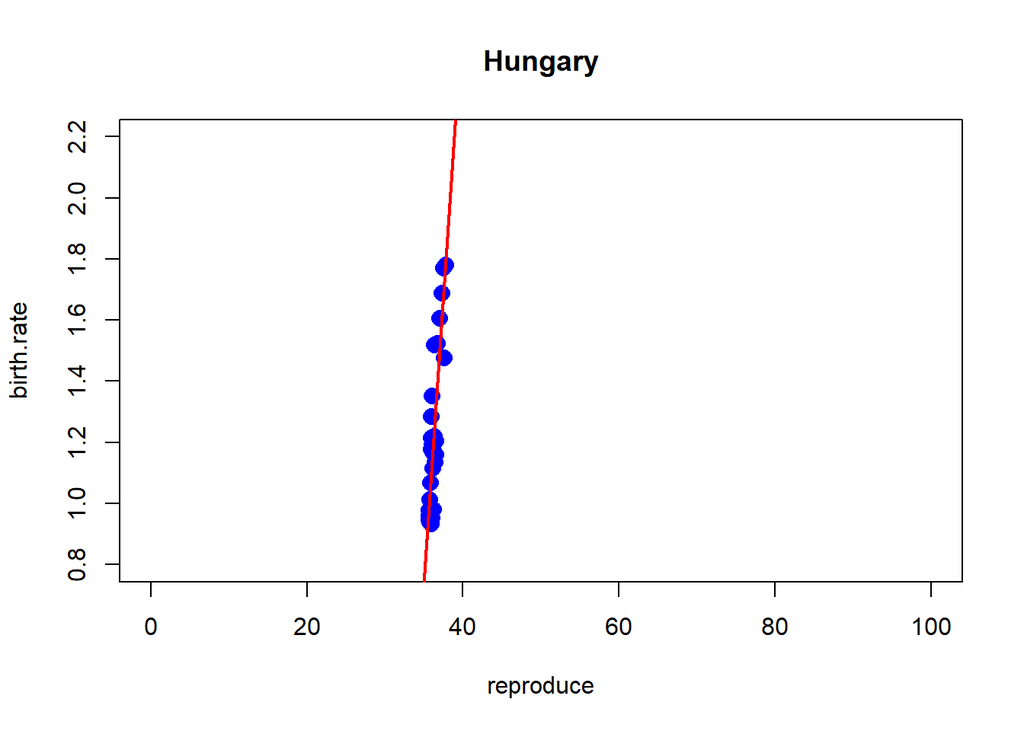

```r
data.Hungary.lm.reproduce <- plot.Country.reproduce(data.Hungary, "Hungary")
```

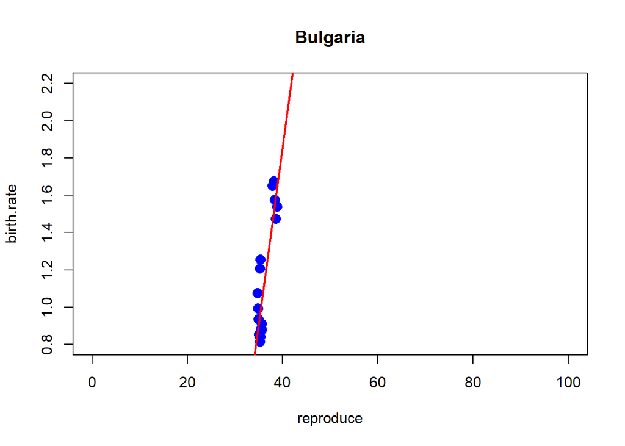

```r
data.Bulgaria.lm.reproduce <- plot.Country.reproduce(data.Bulgaria, "Bulgaria")
```

Immedeatly, the model looks much more better

```r
summary(data.Poland.lm.reproduce)
```

```
##
## Call:
## lm(formula = birth.rate ~ reproduce, data = data.Country)
##
## Residuals:
##      Min       1Q   Median       3Q      Max
## -0.28892 -0.07132  0.04816  0.10068  0.17566
##
## Coefficients:
##             Estimate Std. Error t value Pr(>|t|)
## (Intercept) -9.58964    0.81963  -11.70 2.70e-12 ***
## reproduce    0.28422    0.02095   13.57 7.79e-14 ***
## ---
## Signif. codes:  0 '***' 0.001 '**' 0.01 '*' 0.05 '.' 0.1 ' ' 1
##
## Residual standard error: 0.1352 on 28 degrees of freedom
## Multiple R-squared:  0.868,  Adjusted R-squared:  0.8633
## F-statistic: 184.1 on 1 and 28 DF,  p-value: 7.789e-14
```

The determination coefficient is even better than the one for model using only mean age (0.7647 vs 0.6537)

Poland: 0.868

Bulgraria: 0.7693

Combining the knowledge of population age structure and mean age produces an accurate multilinear model

```r
data.Poland.lm <- lm(birth.rate ~reproduce + mean.age, data = data.Poland)
data.Hungary.lm <- lm(birth.rate ~reproduce + mean.age, data = data.Hungary)
data.Bulgaria.lm <- lm(birth.rate ~reproduce + mean.age, data = data.Bulgaria)
```

```r
summary(data.Poland.lm)
```

```
##
## Call:
## lm(formula = birth.rate ~ reproduce + mean.age, data = data.Poland)
##
## Residuals:
##      Min       1Q   Median       3Q      Max
## -0.23452 -0.07040  0.01535  0.05508  0.18855
##
## Coefficients:
##             Estimate Std. Error t value Pr(>|t|)
## (Intercept) -3.95727    1.48402  -2.667 0.012787 *
## reproduce    0.20869    0.02439   8.557 3.59e-09 ***
## mean.age    -0.07876    0.01867  -4.219 0.000248 ***
## ---
## Signif. codes:  0 '***' 0.001 '**' 0.01 '*' 0.05 '.' 0.1 ' ' 1
##
## Residual standard error: 0.1069 on 27 degrees of freedom
## Multiple R-squared:  0.9204, Adjusted R-squared:  0.9145
## F-statistic: 156.2 on 2 and 27 DF,  p-value: 1.444e-15
```

```r
summary(data.Hungary.lm)
```

```
##
## Call:
## lm(formula = birth.rate ~ reproduce + mean.age, data = data.Hungary)
##
## Residuals:
##       Min        1Q    Median        3Q       Max
## -0.236371 -0.040527 -0.002469  0.055464  0.177247
##
## Coefficients:
##             Estimate Std. Error t value Pr(>|t|)
## (Intercept) -4.89732    1.50627  -3.251  0.00299 **
## reproduce    0.26211    0.03106   8.438 3.55e-09 ***
## mean.age    -0.09074    0.01446  -6.276 8.73e-07 ***
## ---
## Signif. codes:  0 '***' 0.001 '**' 0.01 '*' 0.05 '.' 0.1 ' ' 1
##
## Residual standard error: 0.08173 on 28 degrees of freedom
## Multiple R-squared:  0.9022, Adjusted R-squared:  0.8953
## F-statistic: 129.2 on 2 and 28 DF,  p-value: 7.281e-15
```

```r
summary(data.Bulgaria.lm)
```

```
##
## Call:
## lm(formula = birth.rate ~ reproduce + mean.age, data = data.Bulgaria)
##
## Residuals:
##      Min       1Q   Median       3Q      Max
## -0.14894 -0.09339  0.00381  0.08860  0.13282
##
## Coefficients:
##             Estimate Std. Error t value Pr(>|t|)
## (Intercept)  1.75674    1.70667   1.029 0.319635
## reproduce    0.06877    0.03084   2.230 0.041430 *
## mean.age    -0.08273    0.01763  -4.692 0.000289 ***
## ---
## Signif. codes:  0 '***' 0.001 '**' 0.01 '*' 0.05 '.' 0.1 ' ' 1
##
## Residual standard error: 0.1036 on 15 degrees of freedom
## Multiple R-squared:  0.9065, Adjusted R-squared:  0.894
## F-statistic: 72.71 on 2 and 15 DF,  p-value: 1.91e-08
```

R-squared Poland: 0.9204

R-squared Hungary: 0.9022

R-squared Bulgaria: 0.9065

In three cases mean.age coefficient is similar

Conclusion:

The the birth rate depends on population mean age and age structure. The increase in age is followed by decrease in birthrate and increase in proportion of people, who can reproduce, is followed by increase in the birthrate.

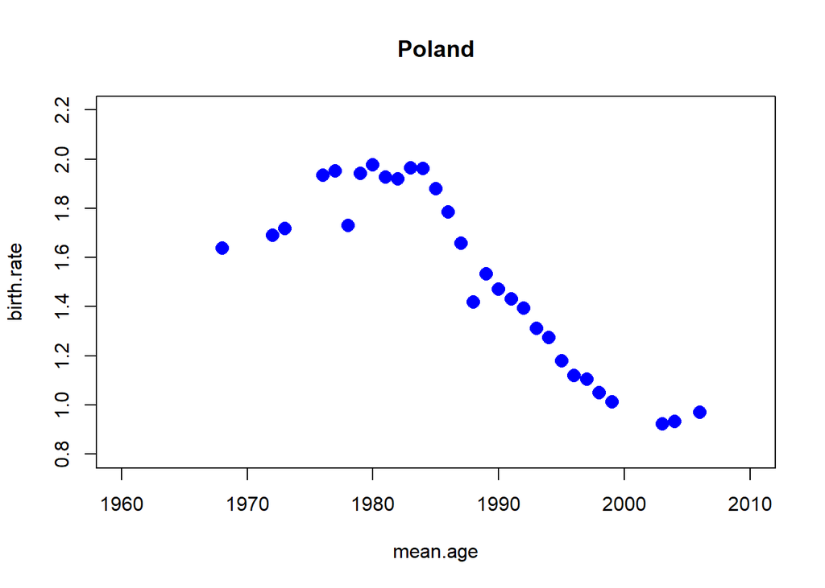

```r
plot(data.Poland$year, data.Poland$birth.rate, col = "blue", pch = 16, main = "Poland", cex = 1.5, xlim = c(1960, 2010), ylim = c(0.8, 2.2), xlab="mean.age", ylab="birth.rate")
```

The birthrate improved a little around the time the countries joined the EU, so population age might not be the only factor in the birthrate